# Gas transfer (DLCO % predicted) in adults with and without HIV

Dataset 11: HIV infection and exercise capacity

RSR feasibility analysis

2026-08-03

# Introduction

The Pittsburgh/UCSF lung-function study enrolled adults living with HIV and HIV-uninfected comparators from two US clinical centres and assessed all of them identically with a six-minute walk test, spirometry, diffusing capacity and the St George’s Respiratory Questionnaire (Fitzpatrick and colleagues, *PLOS ONE* 2019). This teaching extract holds 427 participants, 297 of them living with HIV. The diffusing capacity of the lung for carbon monoxide, expressed as a percentage of the value predicted for a person of the same age, sex and height, measures how efficiently gas crosses from alveolus to blood; it is abnormal in emphysema, interstitial disease and pulmonary vascular disease, and in the source paper it is the lung-function measurement most strongly related to how far participants could walk.

**Aim.** Among these adults, we examined which of HIV status, age, sex, current smoking, cumulative pack-years, blood pressure, haemoglobin and the two spirometric volumes (FEV1 and FVC, each as a percentage of predicted) are independently associated with DLCO % predicted, mutually adjusting for the others.

This is a *Purpose 3* analysis: several predictors are of interest and the question is which remain associated with the outcome after mutual adjustment.

# Methods

**Data source.** A cross-sectional analysis of participants enrolled at two US clinical centres (Pittsburgh and San Francisco) into a cohort study of lung function in HIV. The extract contains 427 adults aged 21 to 79 and 21 variables; 297 (69.6%) are living with HIV. All measurements were made at a single study visit.

**Variables.** The outcome is `dlco_pct_predicted`, single-breath diffusing capacity for carbon monoxide as a percentage of the predicted value (observed range 14.4 to 130.9), treated as continuous. Predictors are HIV status (reference HIV-negative, the clinically unexposed group), age (years), sex (reference male, the larger group), current smoking (reference not a current smoker), cumulative smoking exposure (pack-years), systolic and diastolic blood pressure (mmHg), haemoglobin (g/dL), and FEV1 and FVC each as a percentage of predicted. DLCO itself is of course removed from the predictor set.

**Both spirometric volumes are retained, and the reason is worth stating.** FEV1 and FVC as percentages of predicted correlate at 0.87 in this file, which is high enough to inflate their standard errors. They are nonetheless kept together here because, unlike in the model where FEV1 is the outcome, neither is a re-reading of the outcome: DLCO comes from a separate single-breath manoeuvre. Keeping both lets the model distinguish restriction (low FVC) from obstruction (low FEV1 relative to FVC), which is exactly the distinction that matters for gas transfer. The cost is reported explicitly in the Diagnostics section as a variance inflation factor.

**Smoking is entered once, as dose plus a current-smoking indicator.** The shipped `smoking_status` variable has three levels (never 132, former 106, current 189) and `pack_years` is **exactly zero for all 132 never-smokers and strictly positive for every ever-smoker**, so the two encode the same never/ever distinction twice. Entering the untouched factor alongside pack-years would force the former- and current-smoker contrasts to be estimated at zero pack-years, a value no ever-smoker in this sample has. We therefore keep `pack_years` as the cumulative-dose term and add one binary indicator for *current* smoking. That distinction is more than cosmetic for this outcome: current smoking raises carboxyhaemoglobin, which lowers measured DLCO on the day of the test independently of any lifetime damage.

**Variables deliberately excluded.** `cd4_count`, `on_antiretroviral` and `viral_load_detectable` are **missing by design** for participants without HIV; including any of them deletes most or all of the HIV-negative comparison group. `mmrc_dyspnoea` is excluded because all 111 of its missing values fall in HIV-positive participants, and because breathlessness is downstream of impaired gas transfer. `fev1_fvc_ratio` is excluded because it is very largely a function of the two %-predicted values already in the model (regressing it on them gives R-squared 0.89). The SGRQ scores and `six_min_walk_m` are consequences of lung function and are analysed as separate outcomes.

**Statistical analysis.** `lm()`, justified because the outcome is a continuous, approximately symmetric percentage (skewness -0.16). We fitted a univariable model for each predictor first, then a single multivariable model containing all of them. Predictors were chosen in advance on subject-matter grounds, not by significance. Significance threshold 0.05; estimates are reported with 95% confidence intervals. Assumptions were checked with `performance::check_model()`, and `check_collinearity()` was inspected specifically because of the FEV1/FVC pair. Analysis used R version 4.6.0 (2026-04-24) with tidyverse, gtsummary and performance.

**Parameter budget.** The model estimates 10 parameters on 410 complete cases, about 41 observations per parameter, well inside the 10-15 rule.

**Missing data.** Complete-case analysis: 410 of 427 rows were analysed (17 dropped). The outcome itself is 99.5% complete (2 missing); the loss is mostly haemoglobin (9 missing), spirometry (5) and blood pressure (3). The analytic sample keeps 284 participants with HIV and 126 without.

# Results

## Sample characteristics

**Table 1. Sample characteristics (complete-case analytic sample).**

| **Characteristic** | **N** | **N = 410**<sup>1</sup> |
| --- | --- | --- |
| DLCO (% predicted) | 410 | 81 (70, 91) |
| Living with HIV | 410 | 284 (69%) |
| Age (years) | 410 | 52 (45, 57) |
| Sex | 410 |  |
| Male |  | 254 (62%) |
| Female |  | 156 (38%) |
| Current smoker | 410 | 181 (44%) |
| Smoking (pack-years) | 410 | 7 (0, 23) |
| Systolic BP (mmHg) | 410 | 125 (115, 138) |
| Diastolic BP (mmHg) | 410 | 80 (72, 88) |
| Haemoglobin (g/dL) | 410 | 13.90 (12.70, 14.80) |
| FEV1 (% predicted) | 410 | 92 (78, 104) |
| FVC (% predicted) | 410 | 90 (80, 101) |

<sup>1</sup> Median (Q1, Q3); n (%)

Median DLCO is 81% of predicted and 196 (48%) of participants fall below the conventional 80% lower limit, so impaired gas transfer is the modal abnormality in this sample even though median FEV1 (92% of predicted) and median FVC (90%) are essentially normal.

## Exploratory figure

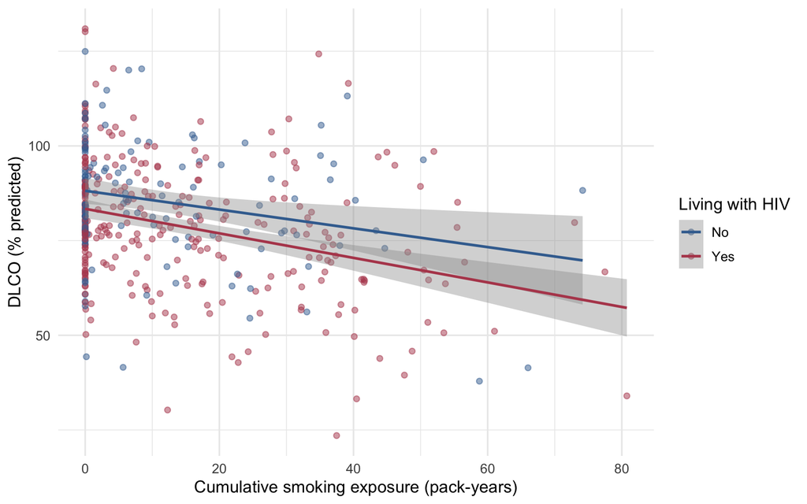

Figure 1. DLCO (% predicted) against cumulative smoking exposure, by HIV status.

Gas transfer falls as lifetime tobacco exposure rises in both groups, and the HIV-positive line sits below the HIV-negative one across the whole range, so the two exposures appear to act additively rather than one explaining the other.

## Univariable models

| **Characteristic** | **N** | **Beta** | **95% CI** | **p-value** |
| --- | --- | --- | --- | --- |
| Living with HIV | 410 |  |  |  |
| No |  | — | — |  |
| Yes |  | -6.7 | -10, -3.2 | <0.001 |
| Age (years) | 410 | -0.33 | -0.49, -0.18 | <0.001 |
| Sex | 410 |  |  |  |
| Male |  | — | — |  |
| Female |  | 7.9 | 4.6, 11 | <0.001 |
| Current smoker | 410 |  |  |  |
| No |  | — | — |  |
| Yes |  | -5.8 | -9.1, -2.5 | <0.001 |
| Smoking (pack-years) | 410 | -0.32 | -0.41, -0.22 | <0.001 |
| Systolic BP (mmHg) | 410 | 0.07 | -0.04, 0.17 | 0.2 |
| Diastolic BP (mmHg) | 410 | 0.03 | -0.13, 0.18 | 0.7 |
| Haemoglobin (g/dL) | 410 | 0.04 | -0.97, 1.0 | >0.9 |
| FEV1 (% predicted) | 410 | 0.42 | 0.35, 0.50 | <0.001 |
| FVC (% predicted) | 410 | 0.47 | 0.38, 0.56 | <0.001 |

Abbreviation: CI = Confidence Interval

Crudely, participants living with HIV have lower diffusing capacity, -6.72 percentage points (95% CI -10.25 to -3.19) of predicted (p <0.001). The spirometric volumes track the outcome closely — 0.42 percentage points (95% CI 0.35 to 0.50) per percentage point of predicted FEV1 (p <0.001) and 0.47 percentage points (95% CI 0.38 to 0.56) per percentage point of predicted FVC (p <0.001) — as does smoking, with each pack-year associated with -0.32 percentage points (95% CI -0.41 to -0.22) (p <0.001) and current smokers -5.82 percentage points (95% CI -9.11 to -2.54) below non-current smokers (p <0.001). Each additional year of age is associated with -0.33 percentage points (95% CI -0.49 to -0.18) (p <0.001) and women average 7.93 percentage points (95% CI 4.61 to 11.25) above men (p <0.001). **Haemoglobin shows no crude association whatever**, 0.04 percentage points (95% CI -0.97 to 1.04) (p = 0.945); this turns out to be the most interesting number in the table. Neither blood pressure is crudely associated.

## Why adjustment is needed

**Cumulative smoking** is the primary confounder of the HIV association. Participants with HIV have smoked more (mean 14.5 pack-years versus 11.4 in the HIV-negative group), and pack-years is one of the strongest crude predictors of DLCO, so part of the crude HIV deficit is a tobacco deficit and the whole question is how much of it survives. **Sex** is the second, and it is the variable that makes this model worth fitting. Men are over-represented in the HIV-positive group (65% versus 54%), men have markedly higher haemoglobin (mean 14.4 versus 12.7 g/dL) and men in this sample have distinctly lower DLCO % predicted (mean 78% versus 86%). Because higher haemoglobin should physiologically *raise* measured DLCO while being commoner in the sex with *lower* DLCO, sex masks the haemoglobin association almost perfectly in the crude analysis. Mutual adjustment lets each estimate be read as a comparison between participants alike on the other measured characteristics.

## Multivariable model

| **Characteristic** | **Beta** | **95% CI** | **p-value** |
| --- | --- | --- | --- |
| Living with HIV |  |  |  |
| No | — | — |  |
| Yes | -3.9 | -6.8, -0.92 | 0.010 |
| Age (years) | -0.23 | -0.37, -0.09 | 0.001 |
| Sex |  |  |  |
| Male | — | — |  |
| Female | 8.0 | 4.7, 11 | <0.001 |
| Current smoker |  |  |  |
| No | — | — |  |
| Yes | -4.1 | -7.1, -1.1 | 0.007 |
| Smoking (pack-years) | -0.14 | -0.23, -0.05 | 0.003 |
| Systolic BP (mmHg) | 0.14 | 0.02, 0.25 | 0.018 |
| Diastolic BP (mmHg) | -0.09 | -0.25, 0.08 | 0.3 |
| Haemoglobin (g/dL) | 1.9 | 0.97, 2.9 | <0.001 |
| FEV1 (% predicted) | 0.23 | 0.09, 0.38 | 0.001 |
| FVC (% predicted) | 0.16 | 0.00, 0.33 | 0.053 |

Abbreviation: CI = Confidence Interval

**Model fit: multivariable linear model for DLCO (% predicted)**

| Statistic | Value |
| --- | --- |
| Complete-case N | 410 |
| Parameters (excl. intercept) | 10 |
| Observations per parameter | 41.0 |
| R-squared | 0.374 |
| Adjusted R-squared | 0.359 |
| Residual SE (% predicted) | 13.6 |

This is the best-fitting of the four models in this dataset: it explains 37.4% of the variance in DLCO % predicted (adjusted R-squared 0.359), with a residual standard deviation of 13.6 percentage points. Among participants of the same age, sex, smoking history, blood pressure, haemoglobin and spirometry, those living with HIV have lower diffusing capacity, -3.86 percentage points (95% CI -6.80 to -0.92) of predicted (p = 0.010), i.e. about 3.9 percentage points lower. Among participants alike on everything else, each additional year of age is associated with -0.23 percentage points (95% CI -0.37 to -0.09) (p = 0.001), each pack-year with -0.14 percentage points (95% CI -0.23 to -0.05) (p = 0.003), and current smoking with -4.11 percentage points (95% CI -7.07 to -1.14) (p = 0.007) — so both the acute and the cumulative smoking terms are independently associated with gas transfer, which was not true for any other outcome in this dataset. Women average 7.95 percentage points (95% CI 4.75 to 11.16) above men (p <0.001), and each g/dL of haemoglobin is associated with 1.91 percentage points (95% CI 0.97 to 2.86) (p <0.001). FEV1 contributes 0.23 percentage points (95% CI 0.09 to 0.38) (p = 0.001) and FVC 0.163 percentage points (95% CI -0.002 to 0.328) (p = 0.053), just short of conventional significance. Systolic pressure is weakly associated (0.14 percentage points (95% CI 0.02 to 0.25), p = 0.018) and diastolic pressure is not. These are associations among the participants observed, not effects of intervening.

## Unadjusted versus adjusted

**Table 2. Unadjusted and adjusted estimates.**

| **Characteristic** | **Unadjusted** **N** | **Unadjusted** **Beta** | **Unadjusted** **95% CI** | **Unadjusted** **p-value** | **Adjusted** **Beta** | **Adjusted** **95% CI** | **Adjusted** **p-value** |
| --- | --- | --- | --- | --- | --- | --- | --- |
| Living with HIV | 410 |  |  |  |  |  |  |
| No |  | — | — |  | — | — |  |
| Yes |  | -6.7 | -10, -3.2 | <0.001 | -3.9 | -6.8, -0.92 | 0.010 |
| Age (years) | 410 | -0.33 | -0.49, -0.18 | <0.001 | -0.23 | -0.37, -0.09 | 0.001 |
| Sex | 410 |  |  |  |  |  |  |
| Male |  | — | — |  | — | — |  |
| Female |  | 7.9 | 4.6, 11 | <0.001 | 8.0 | 4.7, 11 | <0.001 |
| Current smoker | 410 |  |  |  |  |  |  |
| No |  | — | — |  | — | — |  |
| Yes |  | -5.8 | -9.1, -2.5 | <0.001 | -4.1 | -7.1, -1.1 | 0.007 |
| Smoking (pack-years) | 410 | -0.32 | -0.41, -0.22 | <0.001 | -0.14 | -0.23, -0.05 | 0.003 |
| Systolic BP (mmHg) | 410 | 0.07 | -0.04, 0.17 | 0.2 | 0.14 | 0.02, 0.25 | 0.018 |
| Diastolic BP (mmHg) | 410 | 0.03 | -0.13, 0.18 | 0.7 | -0.09 | -0.25, 0.08 | 0.3 |
| Haemoglobin (g/dL) | 410 | 0.04 | -0.97, 1.0 | >0.9 | 1.9 | 0.97, 2.9 | <0.001 |
| FEV1 (% predicted) | 410 | 0.42 | 0.35, 0.50 | <0.001 | 0.23 | 0.09, 0.38 | 0.001 |
| FVC (% predicted) | 410 | 0.47 | 0.38, 0.56 | <0.001 | 0.16 | 0.00, 0.33 | 0.053 |

Abbreviation: CI = Confidence Interval

**Haemoglobin is the striking one.** Crudely it has no association at all with diffusing capacity — 0.04 percentage points (95% CI -0.97 to 1.04), p = 0.945, an estimate indistinguishable from zero — yet adjusted it is one of the strongest terms in the model, 1.91 percentage points (95% CI 0.97 to 2.86), p <0.001. This is textbook masking rather than confounding in the usual direction: haemoglobin genuinely raises measured DLCO (more haemoglobin in the capillary bed means more carbon monoxide taken up), but the people with high haemoglobin here are men, and men have lower DLCO % predicted for other reasons. The two influences cancelled almost exactly in the crude estimate. It also tells us something about the data: **the DLCO values in this file are evidently *not* haemoglobin-corrected**, since a properly corrected DLCO would show no residual haemoglobin association.

Two predictors attenuate substantially but survive. **HIV status** moves from -6.72 percentage points (95% CI -10.25 to -3.19) crude to -3.86 percentage points (95% CI -6.80 to -0.92) adjusted, so roughly 43% of the crude deficit is explained by the other measured characteristics — mostly smoking — but a deficit of about 4 percentage points remains and stays significant. **Pack-years** moves from -0.32 percentage points (95% CI -0.41 to -0.22) to -0.14 percentage points (95% CI -0.23 to -0.05) for the same reason in reverse, sharing its crude effect with current smoking and the spirometric volumes. **FVC** moves the furthest of any term, from 0.47 percentage points (95% CI 0.38 to 0.56) crude (p <0.001) to 0.163 percentage points (95% CI -0.002 to 0.328) adjusted (p = 0.053), losing significance; this is collinearity with FEV1, which itself falls from 0.42 percentage points (95% CI 0.35 to 0.50) to 0.23 percentage points (95% CI 0.09 to 0.38).

## Diagnostics

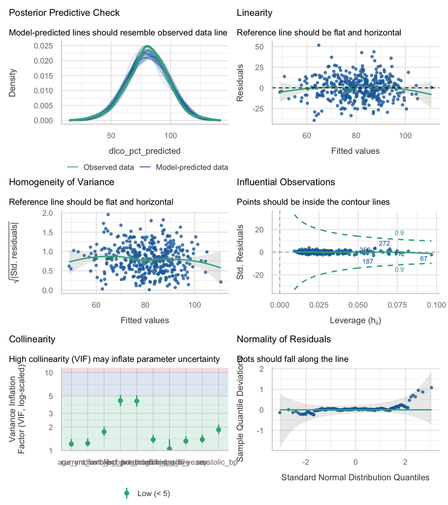

| Term | VIF | VIF_CI_low | VIF_CI_high | SE_factor | Tolerance | Tolerance_CI_low | Tolerance_CI_high |
| --- | --- | --- | --- | --- | --- | --- | --- |
| hiv_positive | 1.049166 | 1.006073 | 1.398068 | 1.024288 | 0.9531378 | 0.7152729 | 0.9939640 |
| age_yrs | 1.212930 | 1.113754 | 1.398571 | 1.101331 | 0.8244498 | 0.7150155 | 0.8978640 |
| sex | 1.384728 | 1.250123 | 1.591773 | 1.176745 | 0.7221633 | 0.6282303 | 0.7999214 |
| current_smoker | 1.238243 | 1.133365 | 1.425600 | 1.112764 | 0.8075957 | 0.7014592 | 0.8823286 |
| pack_years | 1.322367 | 1.199943 | 1.519752 | 1.149942 | 0.7562195 | 0.6580022 | 0.8333729 |
| systolic_bp | 1.844157 | 1.626527 | 2.137384 | 1.357998 | 0.5422530 | 0.4678617 | 0.6148068 |
| diastolic_bp | 1.738213 | 1.539244 | 2.010596 | 1.318413 | 0.5753036 | 0.4973650 | 0.6496695 |
| haemoglobin_g_dl | 1.379481 | 1.245883 | 1.585669 | 1.174513 | 0.7249101 | 0.6306485 | 0.8026436 |
| fev1_pct_predicted | 4.356712 | 3.706967 | 5.162412 | 2.087274 | 0.2295309 | 0.1937079 | 0.2697623 |
| fvc_pct_predicted | 4.298089 | 3.658374 | 5.091745 | 2.073183 | 0.2326616 | 0.1963963 | 0.2733455 |

```
## OK: Error variance appears to be homoscedastic (p = 0.122).
```

Collinearity behaves exactly as anticipated in Methods. The two largest variance inflation factors are 4.36 for FEV1 and 4.30 for FVC, against a maximum of 1.84 for every other term. Both are below the conventional threshold of 5, so the model is estimable and we have kept both, but the practical cost is visible in Table 2: the FVC standard error is 0.084 against 0.043 in the same model with FEV1 removed, and the FVC coefficient loses significance as a result. Neither spirometric coefficient should be quoted on its own. No observation exceeds the Cook’s distance contours (maximum 0.064).

# Discussion

**Limitations.** Participants were recruited at **two clinical centres, Pittsburgh and UCSF, and the site variable is not in this deposit**, although the source paper shows site matters; DLCO measurement in particular is equipment-dependent and calibration differences between laboratories are a plausible source of between-site variation that this model cannot address, so site is both an unmeasured confounder and an ignored clustering variable. The design is cross-sectional. The haemoglobin finding implies that the DLCO values are uncorrected for haemoglobin; readers should not compare these percentages with haemoglobin-corrected values from other cohorts. Smoking is self-reported with no biochemical verification, so residual confounding of the HIV coefficient by under-reported smoking is likely, and it would act in the direction of exaggerating the HIV deficit. FEV1 and FVC compete for the same variance (VIFs 4.4 and 4.3), so the FVC null should not be read as evidence that lung volume is irrelevant. Injecting drug use, prior *Pneumocystis* pneumonia and pulmonary hypertension — all commoner in HIV and all causes of reduced DLCO — are not measured, so the mechanism behind the HIV association cannot be identified here. Complete-case analysis dropped 17 of 427 rows (4.0%). All estimates are associations, not causal effects.

**Future work.** Refit with study site as a fixed effect and with haemoglobin-corrected DLCO, and test formally whether reduced diffusing capacity mediates the HIV association with six-minute walk distance seen in `six_min_walk_m.Rmd`.

# Feasibility notes

*NOT part of a student report.*

- **USABLE, and the strongest of the four outcomes for teaching.** Complete-case N 410 of 427, R-squared 0.374 (the highest of the four models), diagnostics pass, the exposure of interest is significant crudely and adjusted, and the dataset contains a beautiful worked example of masking (haemoglobin). Recommend it.
- **FATAL if any HIV-restricted variable is used.** `cd4_count`, `on_antiretroviral` and `viral_load_detectable` exist only for the 297 participants with HIV. Adding `on_antiretroviral` takes the complete-case N from 410 to 284 with **0 HIV-negative participants remaining**, so `hiv_positive` becomes a constant and `lm()` refuses to fit; adding `cd4_count` takes N to 292 with only 20 HIV-negative participants left, which is the dangerous case because nothing errors. `six_min_walk_m.Rmd` in this folder tabulates the damage in full. Given that this outcome shows the clearest HIV effect in the dataset, destroying the comparison here is the costliest mistake a student can make.
- **MAJOR: FEV1 and FVC compete.** VIFs 4.36 and 4.30 (r = 0.87), against a maximum of 1.84 elsewhere. Below the threshold of 5, so nothing is unestimable, but FVC goes from p <0.001 crude to p = 0.053 adjusted purely because of it. Dropping FEV1 restores FVC to 0.400 with a standard error of 0.043. Students need to be told that a non-significant collinear pair is not evidence of no association.
- **MAJOR (interpretive, not statistical): haemoglobin is completely masked in the crude analysis.** Crude 0.04 percentage points (95% CI -0.97 to 1.04) (p = 0.945), adjusted 1.91 percentage points (95% CI 0.97 to 2.86) (p <0.001). This is a real and well-understood physiological effect (uncorrected DLCO depends on haemoglobin) masked by sex, and it is the best teaching example in the whole dataset — but a student who reports only the univariable table will conclude haemoglobin is irrelevant, and one who reports only the multivariable table without noticing the crude estimate will miss why it matters.
- **MINOR: `mmrc_dyspnoea` is differentially missing** — all 111 missing values are HIV-positive participants; adding it would take N to 302. It is also downstream of the outcome.
- **MINOR: `fev1_fvc_ratio` is near-redundant** with the two %-predicted spirometry variables (R-squared 0.89 regressing it on them). Adding all three to one model is a collinearity disaster waiting to happen; the catalogue lists all three side by side without comment.
- **MINOR: `pack_years` and `smoking_status` are structurally entangled** (`pack_years == 0` is exactly `smoking_status == "never"` on all 427 rows). Unusually for this dataset, *both* smoking terms are independently significant for this outcome (pack-years -0.14 percentage points (95% CI -0.23 to -0.05), current smoking -4.11 percentage points (95% CI -7.07 to -1.14)), so the parameterisation choice has real consequences here and must be justified.
- **MINOR: mildly non-normal residuals** (p = 0.027); variance is constant (p = 0.122).
- **Structural: two-site recruitment with no site variable.** More consequential for DLCO than for the other outcomes, because diffusing-capacity measurement is equipment- and calibration-dependent. Unfixable from the shipped file.